# SpaceKeplerPortfolio

## Importing the libraries

The 'pandas' library provides powerful data structures and data analysis tools, making it easy to handle and manipulate data. The 'numpy' library is used for numerical computations, especially when working with arrays and mathematical operations. The 'matplotlib' library is commonly used for creating static, animated, and interactive visualizations in Python. Lastly, the 'seaborn' library is built on top of 'matplotlib' and provides a higher-level interface for creating attractive and informative statistical graphics.

```python
import pandas as pd  # For data manipulation and analysis
import numpy as np  # For numerical computations
import matplotlib.pyplot as plt  # For data visualization
import seaborn as sns  # For advanced data visualization
```

## Reading and fixing the data

Description of key features in the dataset:

KOI - Kepler Object of Interest.

kepoi_name: A Kepler Object of Interest (KOI) is a target identified by the Kepler Project that exhibits at least one transit-like pattern within the Kepler time-series photometry. These patterns are believed to be of astrophysical origin and initially consistent with the hypothesis of a planetary transit.

kepler_name: These names are specifically assigned to objects that have been confirmed or validated as planets, indicating a higher status than being classified as a planet candidate.

koi_disposition: The classification or status given to this exoplanet candidate in scientific literature. It can be one of the following: CANDIDATE, FALSE POSITIVE, NOT DISPOSITIONED, or CONFIRMED.

koi_pdisposition: The classification given to this exoplanet candidate based on Kepler data analysis. It can be one of the following: FALSE POSITIVE, NOT DISPOSITIONED, or CANDIDATE.

koi_score: A value ranging from 0 to 1 that represents the confidence level associated with the KOI disposition. A higher value indicates greater confidence for CANDIDATEs, while for FALSE POSITIVEs, a higher value implies less confidence.

koi_fpflag_nt: A KOI whose light curve does not align with the pattern observed in a transiting planet. This category includes various factors such as instrumental artifacts, non-eclipsing variable stars, and spurious detections with very low signal-to-noise ratio.

koi_fpflag_ss: A KOI that exhibits a significant secondary event, irregular transit shape, or out-of-eclipse variability. This suggests that the transit-like event is likely caused by an eclipsing binary system. However, self-luminous, hot Jupiters with a visible secondary eclipse may also have this flag set, but with a disposition of PC.

koi_fpflag_co: Indicates that the source of the signal originates from a nearby star, as determined by measuring the centroid location of the image both during and outside of transit, or by comparing the transit signal strength in the target's outer (halo) pixels to that in the optimal (or core) aperture pixels.

koi_srad: The photospheric radius of the star.

koi_kepmag: This represents the Kepler band used for observations.

koi_period: The time interval between successive planetary transits.

```python
kepler_df = pd.read_csv('cumulative.csv', sep = ',')  # Reading the dataset
```

Let's look into the dataset

```python
kepler_df.head(5)
```

|  | rowid | kepid | kepoi_name | kepler_name | koi_disposition | koi_pdisposition | koi_score | koi_fpflag_nt | koi_fpflag_ss | koi_fpflag_co | ... | koi_steff_err2 | koi_slogg | koi_slogg_err1 | koi_slogg_err2 | koi_srad | koi_srad_err1 | koi_srad_err2 | ra | dec | koi_kepmag |
| --- | --- | --- | --- | --- | --- | --- | --- | --- | --- | --- | --- | --- | --- | --- | --- | --- | --- | --- | --- | --- | --- |
| 0 | 1 | 10797460 | K00752.01 | Kepler-227 b | CONFIRMED | CANDIDATE | 1.000 | 0 | 0 | 0 | ... | -81.0 | 4.467 | 0.064 | -0.096 | 0.927 | 0.105 | -0.061 | 291.93423 | 48.141651 | 15.347 |
| 1 | 2 | 10797460 | K00752.02 | Kepler-227 c | CONFIRMED | CANDIDATE | 0.969 | 0 | 0 | 0 | ... | -81.0 | 4.467 | 0.064 | -0.096 | 0.927 | 0.105 | -0.061 | 291.93423 | 48.141651 | 15.347 |
| 2 | 3 | 10811496 | K00753.01 | NaN | FALSE POSITIVE | FALSE POSITIVE | 0.000 | 0 | 1 | 0 | ... | -176.0 | 4.544 | 0.044 | -0.176 | 0.868 | 0.233 | -0.078 | 297.00482 | 48.134129 | 15.436 |
| 3 | 4 | 10848459 | K00754.01 | NaN | FALSE POSITIVE | FALSE POSITIVE | 0.000 | 0 | 1 | 0 | ... | -174.0 | 4.564 | 0.053 | -0.168 | 0.791 | 0.201 | -0.067 | 285.53461 | 48.285210 | 15.597 |
| 4 | 5 | 10854555 | K00755.01 | Kepler-664 b | CONFIRMED | CANDIDATE | 1.000 | 0 | 0 | 0 | ... | -211.0 | 4.438 | 0.070 | -0.210 | 1.046 | 0.334 | -0.133 | 288.75488 | 48.226200 | 15.509 |

5 rows × 50 columns

```python
print(kepler_df.shape)
kepler_df.info()
```

[output not shown]

[output cut: 42 more lines]

```python
kepler_df.describe()
```

[output not shown]

Let's create a new DataFrame called name_score that contains only the columns "kepler_name" and "koi_score" from the kepler DataFrame

```python
name_score = kepler_df[["kepler_name", "koi_score"]]
print(name_score.head(10))
```

```
    kepler_name  koi_score
0  Kepler-227 b      1.000
1  Kepler-227 c      0.969
2           NaN      0.000
3           NaN      0.000
4  Kepler-664 b      1.000
5  Kepler-228 d      1.000
6  Kepler-228 c      1.000
7  Kepler-228 b      0.992
8           NaN      0.000
9  Kepler-229 c      1.000
```

```python
# Check for missing values in each column
print(kepler_df.isnull().sum())
```

[output not shown]

```python
kepler_df.fillna(0)
```

[output not shown]

Let's drop 'rowid' column

```python
kepler_df = kepler_df.drop('rowid', axis = 1)  # Dropping the rowid column
kepler_df.sample()
```

|  | kepid | kepoi_name | kepler_name | koi_disposition | koi_pdisposition | koi_score | koi_fpflag_nt | koi_fpflag_ss | koi_fpflag_co | koi_fpflag_ec | ... | koi_steff_err2 | koi_slogg | koi_slogg_err1 | koi_slogg_err2 | koi_srad | koi_srad_err1 | koi_srad_err2 | ra | dec | koi_kepmag |
| --- | --- | --- | --- | --- | --- | --- | --- | --- | --- | --- | --- | --- | --- | --- | --- | --- | --- | --- | --- | --- | --- |
| 267 | 8414716 | K00910.01 | Kepler-721 b | CONFIRMED | CANDIDATE | 1.0 | 0 | 0 | 0 | 0 | ... | -155.0 | 4.589 | 0.024 | -0.102 | 0.801 | 0.106 | -0.057 | 284.43051 | 44.48053 | 15.651 |

1 rows × 49 columns

Let's make a dataframe with only confirmed planets

```python
confirmed_planets_df = kepler_df[kepler_df['koi_disposition'] == 'CONFIRMED']
```

## Class distribution

The class distribution plot provides a visual representation of the number of instances in each class of the "koi_disposition" variable. From the plot, we can see the following:

- "FALSE POSITIVE": There are 5,023 instances classified as "FALSE POSITIVE."
- "CONFIRMED": There are 2,293 instances classified as "CONFIRMED."
- "CANDIDATE": There are 2,248 instances classified as "CANDIDATE."

This distribution gives us an understanding of the relative proportions of each class within the dataset. It indicates that the majority class is "FALSE POSITIVE," while "CONFIRMED" and "CANDIDATE" classes have similar numbers of instances.

Analyzing the class distribution is essential for assessing class imbalances, understanding the dataset's composition, and selecting appropriate modeling techniques or strategies.

```
FALSE POSITIVE    5023
CONFIRMED         2293
CANDIDATE         2248
Name: koi_disposition, dtype: int64
```

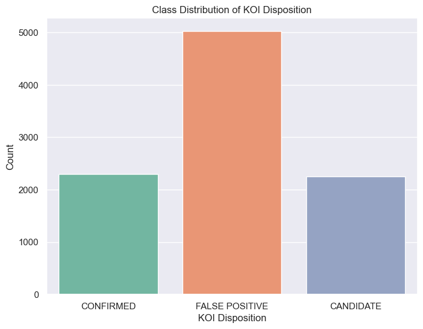

```python
class_counts = kepler_df['koi_disposition'].value_counts()
print(class_counts)

# Class distribution plot
sns.set(style="darkgrid")
plt.figure(figsize=(8, 6))
sns.countplot(x='koi_disposition', data=kepler_df, palette='Set2')
plt.xlabel('KOI Disposition')
plt.ylabel('Count')
plt.title('Class Distribution of KOI Disposition')

plt.show()
```

## Orbital periods of Confirmed Planets

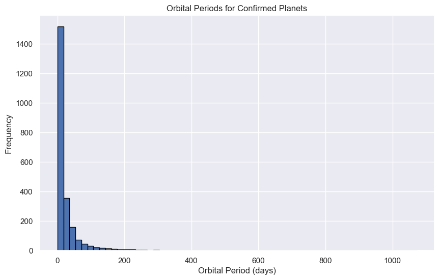

```python
# Plot the distribution of orbital periods
plt.figure(figsize=(10, 6))
plt.hist(confirmed_planets_df['koi_period'], bins=60, edgecolor='black')
plt.xlabel('Orbital Period (days)')
plt.ylabel('Frequency')
plt.title('Orbital Periods for Confirmed Planets')
plt.show()
```

The observed distribution of orbital periods for confirmed planets indicates that a significant majority of these planets have shorter orbital periods. This observation aligns with the logical expectation that planets located closer to their parent stars are more likely to be detected through the method of transit observation. The shorter orbital periods increase the frequency of planetary transits or eclipses, making it more likely for these planets to be observed and confirmed in the dataset.

## Distribution of KOI Score

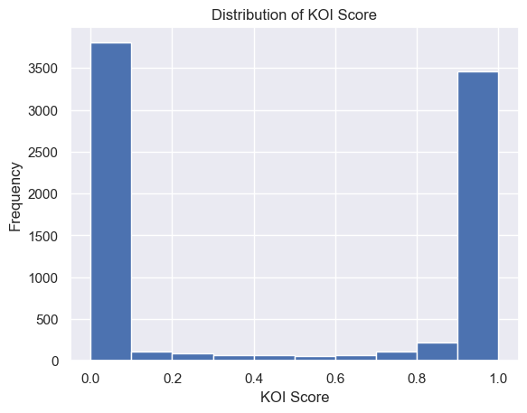

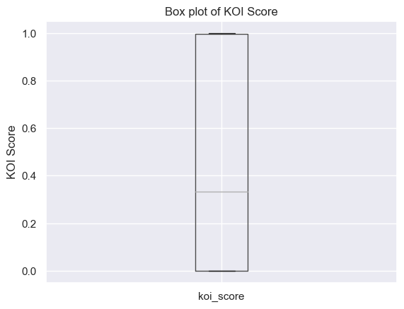

```python
# Histogram
kepler_df['koi_score'].hist()
plt.xlabel('KOI Score')
plt.ylabel('Frequency')
plt.title('Distribution of KOI Score')
plt.show()

# Box plot
kepler_df.boxplot(column='koi_score')
plt.ylabel('KOI Score')
plt.title('Box plot of KOI Score')
plt.show()
```

## Correlation matrix (Note: It is HUGE)

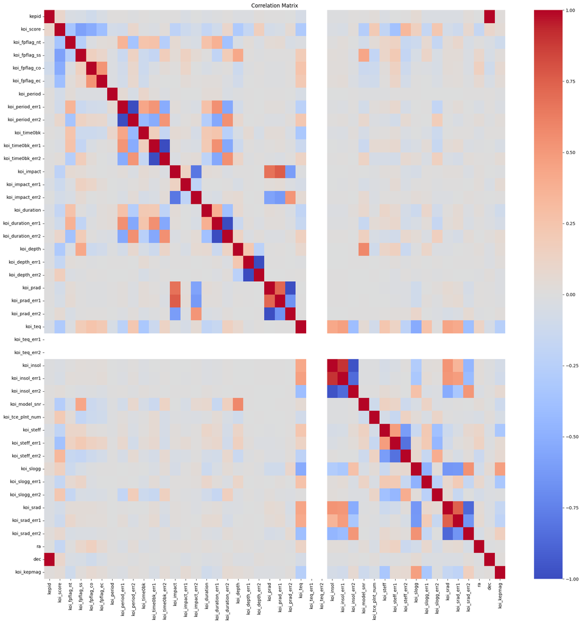

```python
# Calculate the correlation matrix
correlation_matrix = kepler_df.corr()

# Set the figure size
plt.figure(figsize=(20, 20))

# Plot the correlation matrix without numerical values
sns.heatmap(correlation_matrix, annot=False, cmap='coolwarm')
plt.title('Correlation Matrix')

# Adjust the layout to prevent cutoff
plt.tight_layout()

# Display the correlation matrix
plt.show()
```

## Right Ascension and Declination

The plot represents the positions of objects in the sky based on their latitude and longitude coordinates. It's important to note that the plot represents a relatively small patch of the sky, as the telescope observed the same region throughout the mission. Therefore, the distribution of objects is influenced by the specific area observed.

One notable observation is that the density of stars appears to increase on one side of the plot, which corresponds to the side closer to the bulge of the Milky Way. This suggests that the higher concentration of stars in that region contributes to the observed distribution.

Keep in mind that this plot provides a visual representation of the objects' positions in the sky, reflecting the specific area targeted by the telescope during the mission.

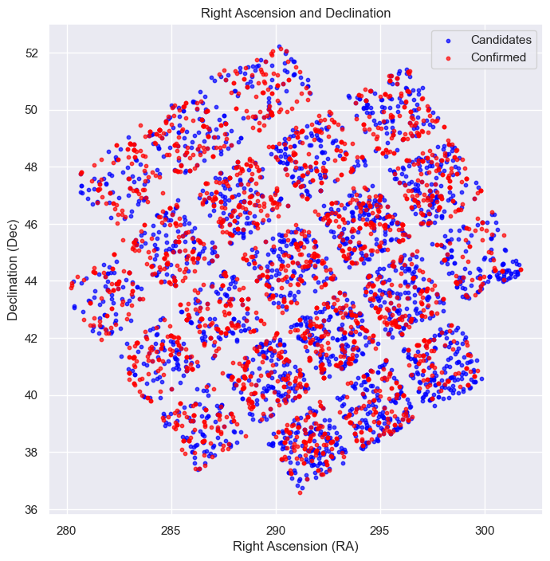

```python
# Separate candidates and confirmed planets
candidates = kepler_df[kepler_df['koi_disposition'] == 'CANDIDATE']
confirmed = kepler_df[kepler_df['koi_disposition'] == 'CONFIRMED']

# Plot Right Ascension (RA) and Declination (Dec) with different colors
plt.figure(figsize=(8, 8))
plt.scatter(candidates['ra'], candidates['dec'], c='blue', label='Candidates', s=10, alpha=0.7)
plt.scatter(confirmed['ra'], confirmed['dec'], c='red', label='Confirmed', s=10, alpha=0.7)

plt.xlabel('Right Ascension (RA)')
plt.ylabel('Declination (Dec)')
plt.title('Right Ascension and Declination')
plt.legend()
plt.show()
```

## Planets magnitudes

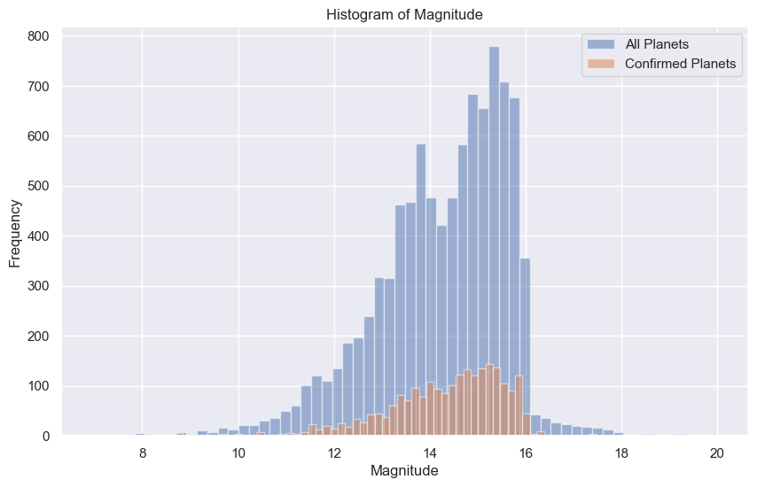

```python
# Filter data for confirmed planets
confirmed_planets = kepler_df[kepler_df['koi_disposition'] == 'CONFIRMED']

# Plot histograms of magnitude for all planets and confirmed planets
plt.figure(figsize=(10, 6))
plt.hist(kepler_df['koi_kepmag'], bins=60, alpha=0.5, label='All Planets')
plt.hist(confirmed_planets['koi_kepmag'], bins=60, alpha=0.5, label='Confirmed Planets')
plt.xlabel('Magnitude')
plt.ylabel('Frequency')
plt.title('Histogram of Magnitude')
plt.legend()
plt.show()
```

The histogram of magnitudes displays an intriguing pattern with what appears to be a bi-modal distribution and a sharp cut-off around the 16th magnitude. Interestingly, this pattern is observed in both the confirmed planets and the entire dataset, suggesting that it is consistent across all planets, regardless of their confirmation status.

- The bi-modal distribution indicates the presence of two distinct populations of planets in terms of their magnitudes. One population likely corresponds to brighter planets with lower magnitudes, while the other population consists of fainter planets with higher magnitudes. The separation between these two groups may suggest inherent differences in the characteristics or properties of the planets.
- The sharp cut-off around the 16th magnitude is particularly noteworthy. It suggests that beyond this magnitude threshold, the noise levels become increasingly prominent, posing challenges for the accurate detection and observation of planetary candidates. Consequently, the sensitivity of the detection method employed by the Kepler spacecraft diminishes significantly beyond this threshold.

It is essential to recognize that these patterns of a bi-modal distribution and the cut-off at the 16th magnitude are observed consistently across both the confirmed planets and the entire dataset. This similarity implies that the detection limitations and noise levels in the search for planetary candidates apply uniformly to all planets.

Understanding these patterns is critical for comprehending the reliability, completeness, and detection constraints of the dataset. Moreover, it aids in establishing appropriate thresholds or criteria for further analysis or classification of planetary candidates.

## Final thoughts

In this data science project, a comprehensive analysis of planetary candidates has been conducted, encompassing various aspects such as class distribution, orbital periods, magnitude distribution, correlation matrix, right ascension and declination, and the distribution of KOI scores. Let's summarize the key findings from each analysis:

- Class Distribution: The dataset consists of three primary classes: "CONFIRMED," "CANDIDATE," and "FALSE POSITIVE." The class distribution revealed an imbalance, with a higher number of instances classified as "FALSE POSITIVE." Addressing this class imbalance is crucial for accurate modeling and analysis.
- Orbital Periods: The analysis of orbital periods unveiled that confirmed planets predominantly exhibit shorter periods. This aligns with the expectation that closer planets to their parent stars are more likely to produce observable transits or eclipses, facilitating their confirmation.
- Magnitude Distribution: The distribution of magnitudes displayed a bi-modal pattern, indicating two distinct groups of planets based on their brightness levels. Moreover, a sharp cut-off at the 16th magnitude suggested the threshold beyond which noise levels make it challenging to detect and characterize planetary candidates.
- Correlation Matrix: The correlation matrix allowed for the assessment of relationships between different numerical variables. Identifying strong positive or negative correlations is useful for understanding interdependencies and potential predictors within the dataset.
- Right Ascension and Declination: The plot of right ascension and declination provided insights into the spatial distribution of objects in the celestial sphere. The data highlighted a concentration of stars towards one side, closer to the bulge of the Milky Way, indicating variations in stellar density across the observed patch of the sky.
- Distribution of KOI Score: The distribution of KOI scores enabled the evaluation of confidence levels associated with planet candidates. Higher scores generally indicated greater confidence, reflecting more reliable candidates with stronger evidence of planetary characteristics.

These diverse analyses shed light on different aspects of the dataset, facilitating a comprehensive understanding of the properties and characteristics of the planetary candidates. It is important to note that these findings are specific to the provided dataset and should be validated and generalized with caution.